# Compare ROMS to NBS Zoop

Genoa Sullaway

11/28/2022

## Background

- I want to see how ROMS and NBS zoop data compare, point to point to inform how I use zooplankton data/ROMS in the AYK prey index.
- I combined the EcoDAAT zoop data and the EMA zoop data (has NBS) using scripts adapted from DK, in scripts/Ecodaat_ema_combine_data.R, this script also converts to biomass. Next I matched in ROMS L2 using scripts/Compare_ROMS_Empirical.R, ROMS is matched to empirical data using nearest neighbor through space and time.
- In Sullaway et al in prep, I did not have this data, so I add it in here. Below, I plot estimated trends from both sources of information from a GAM and I show predicted differences in absolute values between the two. I see if predicted values change through space and time to inform which source of information I should use in the AYK prey index model.
- Right now everything shown is just for Calanus.
- First lets highlight the ROMS region that I crop to compare with zooplankton surveys. Chum are known to distribute to in the EBS - stock specific distributions are in Urawa et al 2009 GSI specific from 2003 surveys.

```r
# plot of ROMS locations
# right now not doing this because I am just comparing point to point, later if I do use ROMS I can include ROMS cropped plot
#Match ROMS and zoop
#check spatial extent of ROMS
# check <- data.frame(unique(ROMS[c("latitude", "longitude")]))
#
# ggplot(data = check) +
#   geom_point(aes(x=longitude, y = latitude))
```

- Plot of all Zoop stations surveyed (irrespective of year)
- This will need a little more work in terms of thinking about how I want to trim the info
- Options - DFA on a smaller area from when they first enter near shore? or option 2 DFA for the whole EBS and let it work itself out…

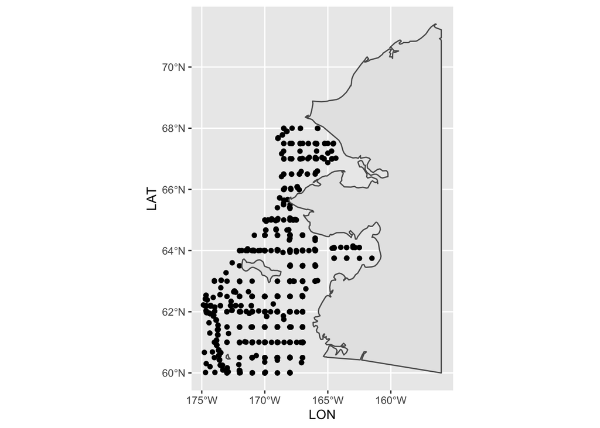

```r
check <- data.frame(unique(df[c("LAT", "LON")]))

ggplot(data = check) +
  geom_point(aes(x=LON, y = LAT)) +
  geom_sf(data = ak)
```

# look at survey stations by year

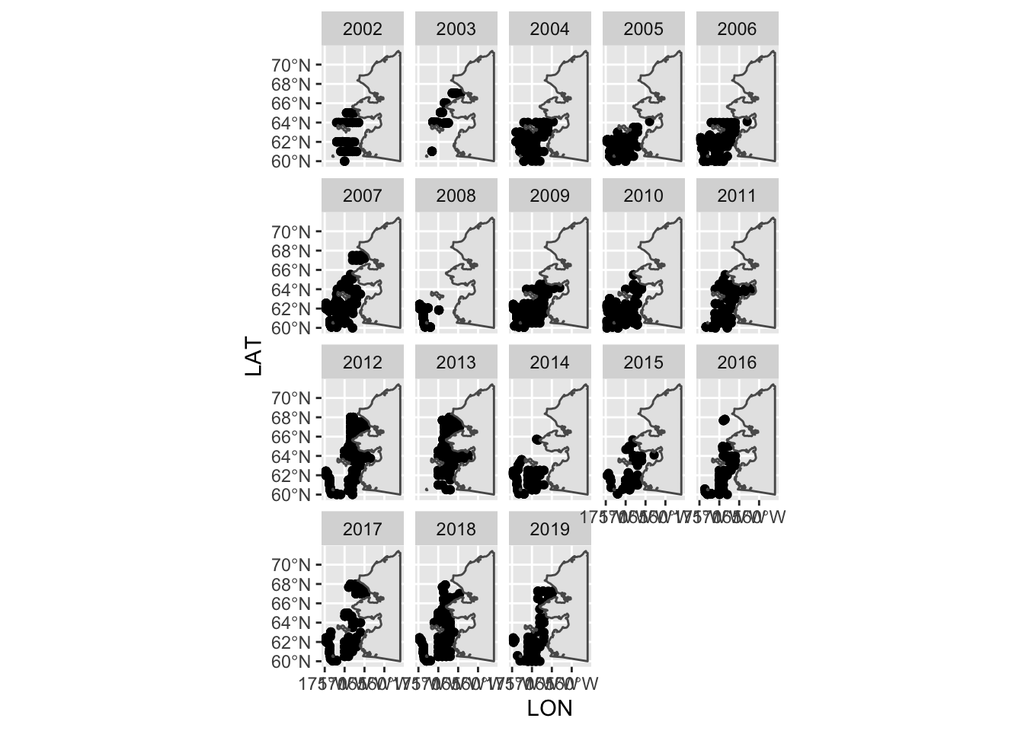

```r
ggplot(data = df) +
  geom_point(aes(x=LON, y = LAT)) +
  geom_sf(data = ak) +
  facet_wrap(~YEAR)
```

- Now I am going to run through some point to point comparisons to see if ROMS and empirical data have similar relative and absolute trends in the NBS.
- Below, I mean-scaled both sources of info (to their own mean) and plotted them to ask if relative values are the same.
- They are generally not - if you run a basic linear model, R2 is <1%.

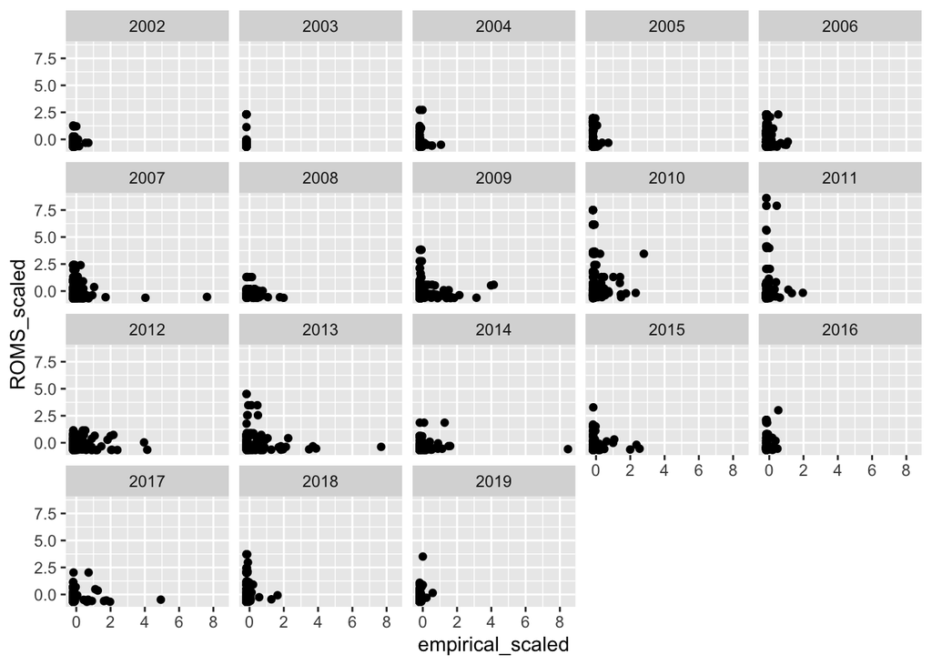

```r
# mean scale and regress the two against each other
df2 <- df %>%
  dplyr::mutate(empirical_scaled = scale(BIOMASS_C_MG_M3_MEAN),
         ROMS_scaled = scale(NCaS)) %>%
   dplyr::filter(!empirical_scaled > 10)

ggplot(df2) +
  geom_point(aes(x= empirical_scaled, y= ROMS_scaled)) +
  facet_wrap(~YEAR)
```

```r
#
# m1 <- lm(ROMS_scaled~empirical_scaled, data = df2)
# summary(m1)
# m2 <- lm(empirical_scaled~ROMS_scaled, data = df2)
# summary(m2)
```

- Now lets see if ROMS is sampled in the same manner as the survey points, do we get similar estimated patterns?

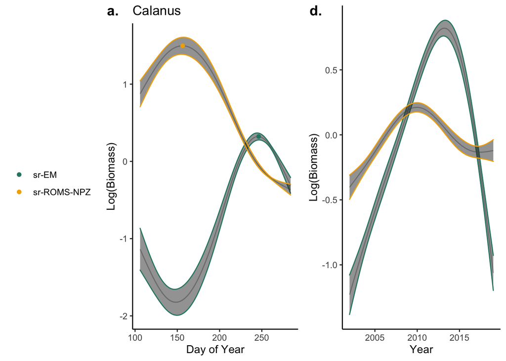

- What do absolute patterns look like?
- Predict biomass from both models across sapce and look at averages for both predictions for both ROMS and Empirical model.
- Result: pretty different, surveys dont get much in these regions compared to what ROMS predicts.

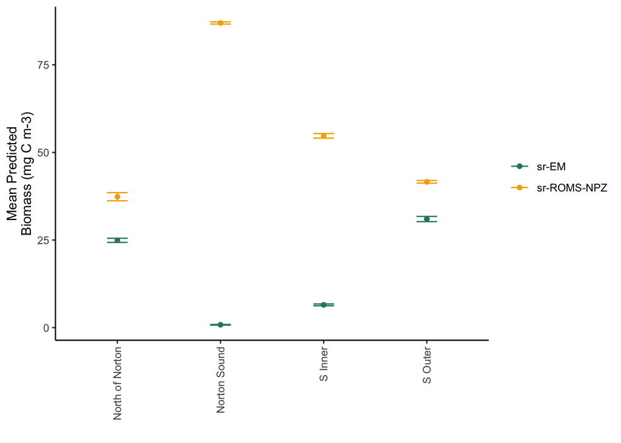

```r
color = c("#2A8572",  "#F2AD00")
#color3 = c("#2A8572",  "#F2AD00", "#808080")

fig3 <- function(sp, df_input){

  pred_eco <- mgcv::gam(BIOMASS_C_MG_M3_MEAN ~ s(day_of_year, k=4) +
                          s(YEAR,k=5) + te(LON, LAT, bs=c("tp", "tp")),
                        data = df_input,
                        family = tw(link = "log"))

  pred_roms <- mgcv::gam(NCaS ~ s(day_of_year, k=4) +
                           s(YEAR, k=5 ) + te(LON, LAT, bs=c("tp", "tp")),
                         data = df_input,
                         family = tw(link = "log"))

############# plot relative difference in biomass

new.dat = data.frame(day_of_year = rep(round(mean(df_input$day_of_year)),
                     times = nrow(df_input)),
                     YEAR = rep(round(mean(df_input$YEAR)), #mean is 2010.8 - just round so it makes more sense..
                                times = nrow(df_input)),
                     LAT = df_input$LAT,
                     LON = df_input$LON)

new.dat <- unique(new.dat[c("day_of_year", "YEAR", "LAT", "LON")])

eco_pred =  predict.gam(pred_eco, newdata = new.dat, se.fit = TRUE)#, type = "response")

roms_pred = predict(pred_roms, newdata = new.dat, se.fit = TRUE)#, type = "response")

pred <- data.frame(eco_pred  =  exp(eco_pred[[1]]),
                   roms_pred  =  exp(roms_pred[[1]]),
                   eco_se  = exp(eco_pred[[2]]),
                   roms_se  =  exp(roms_pred[[2]])) %>%
# pred <- data.frame(eco_pred  =  eco_pred[[1]],
#                    roms_pred  =  roms_pred[[1]],
#                    eco_se  = eco_pred[[2]],
#                    roms_se  = roms_pred[[2]]) %>%
  cbind(new.dat) %>%
  gather(1:4, key = "id", value= "value") %>%
  dplyr::mutate(type = case_when(id %in% c("eco_pred","roms_pred") ~ "prediction",
                                 TRUE ~ "SE"),
                id = case_when(id %in% c("eco_pred", "eco_se") ~ "ECOFOCI",
                               id %in% c("roms_pred", "roms_se") ~ "ROMS",
                               TRUE ~ "check")) %>%
  spread(type , value)


# plot across space

  space <- ggplot(data = pred, aes(x=LON, y=LAT )) +
  geom_point(aes( color = log(prediction))) +
  geom_sf(data = ak, fill= "white", inherit.aes = FALSE) +
  facet_wrap(~id) +
  theme_void() +
  scale_fill_viridis(name = "Log(Biomass)")



diff_df <- pred %>% # set a flag to group by depths to show different areas on the shelf...
   mutate(depth_id = case_when(LON > - 165 & LAT < 66 ~ "Norton Sound",
                               LAT > 64.5 ~ "North of Norton",
                               LON > -170 & LAT <= 64.5 ~ "S Inner",
                               LON <= -170 & LAT <= 64.5 ~ "S Outer",
                               TRUE ~ "check")) %>%
  # mutate(depth_id = case_when(bottom_depth <= 50 ~ "Inner Shelf",
  #                             bottom_depth > 50 & bottom_depth <=100 ~ "Middle Shelf",
  #                             bottom_depth > 100 ~ "Outer Shelf" )) %>%
  group_by(depth_id,id) %>%
  dplyr::summarise(#total_biomass = sum(prediction),
    avg_pred = mean(prediction),
    # se = sd(prediction)/sqrt(length(prediction)),
    #total_weighted_biomass = sum(prediction*SE),
    avg_weighted_biomass = mean(prediction),#*SE),
    #SE_total = sd(prediction*SE)/sqrt(length(prediction*SE))
    SE_total = sd(prediction)/sqrt(length(prediction))) %>%
  dplyr::mutate(species = sp)

return(list(diff_df,space))

}

a<-fig3(df_input = df, sp="Calanus")
# diff_df<-rbind(a,b,c) %>%
#   dplyr::mutate(species = factor(species, levels = c("Calanus", "Pseudocalanus", "Neocalanus")))

diff_plot<-ggplot(data = a[[1]], aes(x=depth_id, y = avg_weighted_biomass, color = id, group = id)) +
  geom_point()+
    geom_errorbar(aes(ymin =  avg_weighted_biomass- SE_total, ymax =  SE_total+ avg_weighted_biomass),
                  width = 0.2) +
  theme_classic() +
  #theme_pubclean() +
  ylab("Mean Predicted\nBiomass (mg C m-3)") +
  xlab("") +
  #facet_wrap(~species, ncol = 1,scales = "free")+
  scale_color_manual(values= color,
                     labels=c("sr-EM", "sr-ROMS-NPZ")) +
  theme(legend.title = element_blank(),
        axis.text.x = element_text(angle = 90, vjust = 0.5, hjust=1))

diff_plot
```

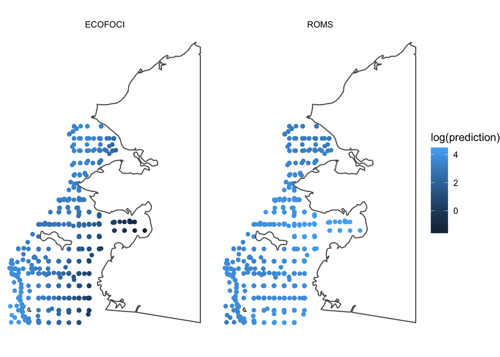

```r
print(a[[2]])
```

```r
#
# a_test <- a %>%
#   mutate(avg_weighted_biomass = case_when(id == "ROMS" ~ avg_weighted_biomass/10,
#                                           TRUE ~ avg_weighted_biomass))
#
# ggplot(data = a_test, aes(x=depth_id, y = avg_weighted_biomass, color = id, group = id)) +
#   geom_point()+
#     geom_errorbar(aes(ymin =  avg_weighted_biomass- SE_total, ymax =  SE_total+ avg_weighted_biomass),
#                   width = 0.2) +
#   theme_classic() +
#   #theme_pubclean() +
#   ylab("Mean Predicted\nBiomass (mg C m-3)") +
#   xlab("") +
#   #facet_wrap(~id, ncol = 1,scales = "free")+
#   scale_color_manual(values= color,
#                      labels=c("sr-EM", "sr-ROMS-NPZ")) +
#   theme(legend.title = element_blank(),
#         axis.text.x = element_text(angle = 90, vjust = 0.5, hjust=1))
```